# Homework 10

Solutions for Questions 1 and 2 will be available after Monday, November 2, 2026. No solution will be provided for Question 3.

Use the RLT package for Questions 1 and 2: `RLT` in R or `rlt` in Python. The node-size parameter is `nmin` in R and `min_samples_leaf` in Python; both stop splitting a node when it contains at most that many observations. The candidate-predictor parameter is `mtry` in both languages. Use ordinary random forests, with reinforcement turned off.

## Question 1: Bias-variance trade-off simulation

Two important tuning parameters of random forests are node size and `mtry`. We have performed some preliminary analysis in class. The goal of this question is to perform a larger simulation study for these two tuning parameters.

Consider a regression model with five jointly normally distributed predictors. Each predictor has mean 0 and variance 1, and the correlation between any two different predictors is 0.3. The response is

$$Y=X_1+X_3+X_5+\varepsilon,
\qquad \varepsilon\sim N(0,1),$$

where the noise is independent of the predictors. Thus the true regression function is $f(\mathbf{x})=x_1+x_3+x_5$.

1. Set up a simulation study with 100 repetitions. Generate 200 test predictor vectors once and keep them fixed. In each repetition, generate 200 new training observations and use the same training data for all tuning settings. Fit 500-tree forests, drawing 200 observations with replacement for each tree. Make the following two comparisons:
   - Fix `mtry` at 3 and vary node size over $1,5,10,20,30$.
   - Fix node size at 10 and vary `mtry` over $1,2,3,4,5$.

   Leave all other fitting parameters at their defaults. Record the predictions at each test point across repetitions. For each setting, estimate the squared bias and variance at each test point, then average them over the 200 test points. Compare predictions with $f(\mathbf{x})$ when estimating bias. Produce two figures, one for each tuning parameter, showing the averaged squared bias and variance. Set a random seed and report it.
2. Discuss your results in terms of the bias-variance trade-off:
   - How does a large node size, such as 30, affect the fit in this example?
   - What are the benefits and drawbacks of using a large `mtry` value?
   - If each tree instead sampled 100 observations with replacement, would you expect the preferred node size to shift toward smaller or larger values? Explain your reasoning. You may use an additional simulation to help, but a particular pattern is not guaranteed.

### Solution: Question One

```r
library(MASS)
library(RLT)
library(ggplot2)

set.seed(432)

p <- 5
n_train <- 200
n_test <- 200
n_rep <- 100

Sigma <- matrix(0.3, p, p)
diag(Sigma) <- 1

f <- function(x) {
  x[, 1] + x[, 3] + x[, 5]
}

x_test <- mvrnorm(n_test, rep(0, p), Sigma)
f_test <- f(x_test)

settings <- unique(rbind(
  data.frame(nmin = c(1, 5, 10, 20, 30), mtry = 3),
  data.frame(nmin = 10, mtry = 1:5)
))

predictions <- array(
  NA_real_,
  dim = c(n_test, n_rep, nrow(settings))
)


for (r in 1:n_rep) {

  x_train <- mvrnorm(n_train, rep(0, p), Sigma)
  y_train <- f(x_train) + rnorm(n_train)

  for (s in 1:nrow(settings)) {

    invisible(capture.output(fit <- RLT(
      x = x_train,
      y = y_train,
      model = "regression",
      ntrees = 500,
      nmin = settings$nmin[s],
      mtry = settings$mtry[s],
      replacement = TRUE,
      resample.prob = 1,
      use.cores = 1,
      print.summary = 0
    )))

    predictions[, r, s] <- predict(fit, x_test)$Prediction
  }
}

results <- settings
results$Bias2 <- NA_real_
results$Variance <- NA_real_

for (s in 1:nrow(settings)) {

  pred <- predictions[, , s]

  mean_pred <- rowMeans(pred)

  bias2 <- (mean_pred - f_test)^2
  variance <- apply(pred, 1, var)

  results$Bias2[s] <- mean(bias2)
  results$Variance[s] <- mean(variance)
}

print(results)
```

```
   nmin mtry     Bias2   Variance
1     1    3 0.2162247 0.10772136
2     5    3 0.2115465 0.09592942
3    10    3 0.2259745 0.07746868
4    20    3 0.2903630 0.06238318
5    30    3 0.3764964 0.05552639
6    10    1 0.6899837 0.03789977
7    10    2 0.3136066 0.05884746
9    10    4 0.1909946 0.09604045
10   10    5 0.1741151 0.11076283
```

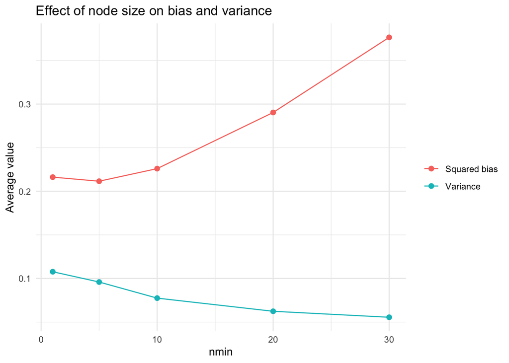

```r
plot_results <- function(data, parameter, title) {
  plot_data <- rbind(
    data.frame(
      Setting = data[[parameter]],
      Value = data$Bias2,
      Metric = "Squared bias"
    ),
    data.frame(
      Setting = data[[parameter]],
      Value = data$Variance,
      Metric = "Variance"
    )
  )

  ggplot(plot_data, aes(Setting, Value, color = Metric)) +
    geom_line() +
    geom_point(size = 2) +
    labs(
      title = title,
      x = parameter,
      y = "Average value",
      color = NULL
    ) +
    theme_minimal()
}

plot_results(
  subset(results, mtry == 3),
  "nmin",
  "Effect of node size on bias and variance"
)
```

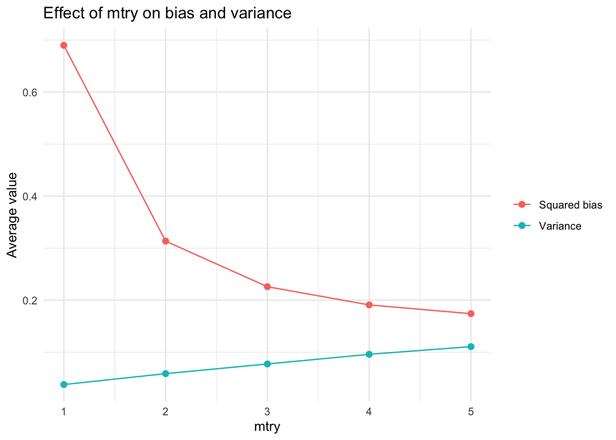

```r
plot_results(
  subset(results, nmin == 10),
  "mtry",
  "Effect of mtry on bias and variance"
)
```

The figures show the average squared bias and variance for each tuning parameter.

Node size: As node size increases, squared bias generally increases while variance decreases. In my simulation, a node size of 30 produced the highest squared bias (0.3765) and lowest variance (0.0555). Larger node sizes restrict the number of splits, producing less flexible trees that may miss important relationships. However, these simpler trees produce more stable predictions across training samples, reducing variance.

mtry: Increasing mtry decreased squared bias but increased variance in my simulation. Larger mtry values allow the model to consider more predictors at each split, increasing the chance of selecting informative predictors and reducing bias. However, the trees may become more similar because they frequently select the same predictors, reducing the variance-reduction benefit of averaging different trees.

Smaller bootstrap samples: If each tree sampled only 100 observations instead of 200, I would expect the preferred node size to potentially shift toward smaller values. With fewer observations available per tree, large node sizes may restrict splitting too much, producing overly simple trees with higher bias. Smaller node sizes would allow the trees to grow deeper and capture more relationships, although they could also increase variance. Therefore, the preferred node size is not guaranteed to shift in a particular direction.

## Question 2: Tuning random forests for MNIST

Use `mnist-first2000.csv.gz` from the combined ZIP. It contains 2,000 MNIST observations, with the digit label `Digit` and 784 pixel values.

- From the first 1,000 observations, keep digits 1, 6, and 7 as the training data. From the remaining 1,000 observations, keep the same digits as the test data.
- Fit PCA to the training pixels, centering but not scaling them. Use the first 20 principal components as predictors, and project the test observations using the same training means and loadings.

Complete the following tasks using RLT classification forests with 1,000 trees. For each tree, draw a bootstrap sample of the same size as the training set.

1. Fit a random forest with the default `mtry` and node-size settings. Report the out-of-bag (OOB) misclassification rate.
2. Construct a grid of `mtry` and node-size values to tune the model. Select the setting using OOB misclassification rate. Report the OOB error for each setting and the selected values. Calculate and present the selected forest’s OOB permutation variable importance for the 20 principal components. Comment on your results.
3. Apply the selected model to the test data and report the misclassification rate and confusion matrix. Use the test labels only for this final assessment.

### Solution: Question Two

```r
set.seed(432)

mnist <- read.csv(
  "data/mnist-first2000.csv.gz"
)

train <- mnist[1:1000, ]
test <- mnist[1001:2000, ]

train <- subset(train, Digit %in% c(1, 6, 7))
test <- subset(test, Digit %in% c(1, 6, 7))

x_train <- train[, names(train) != "Digit"]
x_test <- test[, names(test) != "Digit"]

pca <- prcomp(x_train, center = TRUE, scale. = FALSE)

train_pc <- pca$x[, 1:20]
test_pc <- predict(pca, newdata = x_test)[, 1:20]

y_train <- factor(train$Digit)
y_test <- factor(test$Digit)

rf_default <- RLT(
  x = train_pc,
  y = y_train,
  model = "classification",
  ntrees = 1000,
  resample.prob = 1,
  replacement = TRUE,
  use.cores = 1
)
```

```
Package is not compiled with OpenMP (omp.h).
```

```r
rf_default$Error
```

```r
names(rf_default)
```

```
 [1] "FittedTrees"       "AllError"          "VarImp"
 [4] "ObsTrack"          "ylevels"           "nclass"
 [7] "model"             "n"                 "p"
[10] "variablenames"     "subjectnames"      "ncat"
[13] "xlevels"           "ntrees"            "mtry"
[16] "nmin"              "split.gen"         "nsplit"
[19] "select.method"     "replacement"       "resample.prob"
[22] "npermute"          "subject.weight"    "track.obs"
[25] "importance"        "use.sub.weight"    "reinforcement"
[28] "combsplit"         "parameters.int"    "parameters.double"
```

```r
rf_default$AllError
```

[output not shown]

[output cut: 3949 more lines]

[output not shown]

```r
mean(rf_default$AllError[, "nonPermute"])
```

```
[1] 0.1963411
```

```r
rf_default$mtry
```

```
[1] 6
```

```r
rf_default$nmin
```

```
[1] 5
```

```r
grid <- expand.grid(
  mtry = c(2, 4, 6, 8, 10, 15, 20),
  nmin = c(2, 5, 10, 20)
)

grid$oob_error <- NA_real_

for (i in seq_len(nrow(grid))) {
  set.seed(123)

  fit <- RLT(
    x = train_pc,
    y = y_train,
    model = "classification",
    ntrees = 1000,
    mtry = grid$mtry[i],
    nmin = grid$nmin[i],
    resample.prob = 1,
    replacement = TRUE,
    use.cores = 1,
    importance = TRUE
  )

  grid$oob_error[i] <- mean(fit$AllError[, "nonPermute"])
}
```

[output not shown]

```r
grid[order(grid$oob_error), ]
```

```
   mtry nmin  oob_error
7    20    2 0.09913736
21   20   10 0.10152761
14   20    5 0.10337398
28   20   20 0.10662898
6    15    2 0.11487337
13   15    5 0.11722930
20   15   10 0.11732743
27   15   20 0.12350180
5    10    2 0.14033922
12   10    5 0.14464683
19   10   10 0.15026942
4     8    2 0.15756191
26   10   20 0.15906444
11    8    5 0.16290472
18    8   10 0.17055846
25    8   20 0.17864777
3     6    2 0.18987196
10    6    5 0.19896474
17    6   10 0.20415122
24    6   20 0.21433610
2     4    2 0.23516937
9     4    5 0.24630011
16    4   10 0.25603358
23    4   20 0.26806244
1     2    2 0.31863182
8     2    5 0.32878721
15    2   10 0.33948783
22    2   20 0.36407773
```

```r
set.seed(123)

rf_best <- RLT(
  x = train_pc,
  y = y_train,
  model = "classification",
  ntrees = 1000,
  mtry = 20,
  nmin = 2,
  resample.prob = 1,
  replacement = TRUE,
  use.cores = 1,
  importance = TRUE
)
```

```
Package is not compiled with OpenMP (omp.h).
```

```r
rf_best$VarImp
```

```
          PC1      PC2       PC3        PC4       PC5       PC6       PC7
[1,] 2.300267 4.659163 0.2632993 0.07108323 0.1783946 0.1110863 0.0586415
            PC8        PC9       PC10      PC11       PC12       PC13
[1,] 0.02461805 0.01616851 0.03509334 0.1907598 0.04130604 0.02503741
           PC14       PC15       PC16       PC17       PC18       PC19
[1,] 0.03237184 0.02083128 0.04507416 0.03179799 0.07466108 0.03364686
           PC20
[1,] 0.02271053
```

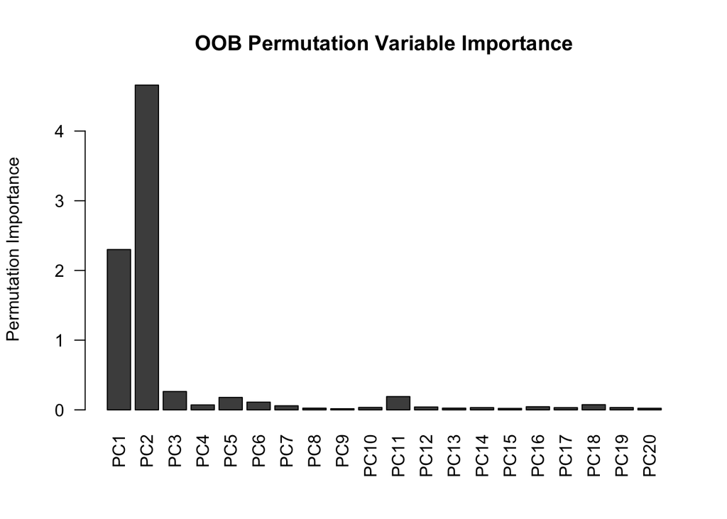

```r
barplot(
  rf_best$VarImp,
  names.arg = paste0("PC", 1:20),
  las = 2,
  main = "OOB Permutation Variable Importance",
  ylab = "Permutation Importance"
)
```

```r
pred <- predict(rf_best, test_pc)

pred_values <- if (is.list(pred)) {
  pred$Prediction
} else {
  pred
}

pred_class <- factor(
  as.vector(pred_values),
  levels = 0:2,
  labels = levels(y_train)
)

confusion_matrix <- table(
  Actual = y_test,
  Predicted = pred_class
)

test_error <- mean(pred_class != y_test)

confusion_matrix
```

```
      Predicted
Actual   1   6   7
     1 103   0   1
     6   1 105   0
     7   0   3 104
```

```r
test_error
```

```
[1] 0.01577287
```

```r
confusion_matrix <- table(
  Actual = y_test,
  Predicted = pred_class
)

confusion_matrix
```

```
      Predicted
Actual   1   6   7
     1 103   0   1
     6   1 105   0
     7   0   3 104
```

```r
1 - sum(diag(confusion_matrix)) / sum(confusion_matrix)
```

```
[1] 0.01577287
```

```r
pred_class <- factor(
  pred$Prediction,
  levels = 0:2,
  labels = levels(y_train)
)

confusion_matrix <- table(
  Actual = y_test,
  Predicted = pred_class
)

test_error <- mean(pred_class != y_test)

confusion_matrix
```

```
      Predicted
Actual   1   6   7
     1 103   0   1
     6   1 105   0
     7   0   3 104
```

```r
test_error
```

```
[1] 0.01577287
```

I fitted an RLT classification random forest using the first 20 principal components, 1,000 trees, and bootstrap sampling with replacement. The default parameters were mtry = 6 and nmin = 5. The model produced an average individual-tree out-of-bag (OOB) misclassification rate of 19.63%.

I tuned the random forest by testing 28 combinations of mtry and nmin, selecting the combination with the lowest average individual-tree OOB misclassification rate. The best combination was mtry = 20 and nmin = 2, with an error rate of 9.91%, compared to 19.63% for the default model. Generally, increasing mtry and decreasing nmin improved performance under this criterion.

The OOB permutation importance results showed that PC2 (4.6592) and PC1 (2.3003) were by far the most important predictors. The remaining components had substantially lower importance values. Interestingly, PC2 was more important than PC1, demonstrating that the principal component explaining the most variance is not necessarily the most useful for classification.

Using the selected random forest, I obtained a test misclassification rate of 1.58%, with 5 incorrect predictions out of 317 test observations. The model correctly classified 312 of the 317 test observations, achieving an accuracy of approximately 98.42%. Most errors involved misclassifying digit 7 as digit 6. Overall, the model performed well on the independent test set.

## Question 3: Planning a random-forest analysis skill

In earlier homework, some students wrote long skill files with detailed instructions, while others wrote short skills emphasizing their specific requirements or references. These approaches may perform differently depending on the AI and the task. A capable AI may already know standard ways to perform an analysis, so some instructions may be redundant, add little value, or sometimes make the analysis worse. It may be more useful to specify your personal choices for the analysis. An AI with more limited knowledge may benefit from detailed instructions that remind it of the steps to perform.

1. Write one paragraph describing how you would write a skill that directs an AI to perform a random-forest analysis and produce a report for a future dataset. Discuss how you would balance standard analysis instructions with your personal preferences, considering the AI’s capabilities.
2. Provide **10 instructions** you would consider including in the skill, **ordered from the most basic instructions to the more personal preferences**. Your list may cover computation, tuning, tables, figures, interpretation, presentation, or other aspects of a random-forest report.

You only need to discuss how the skill should be written. You are not required to write a complete skill file or test it.

### Solution: Question Three

I would write the skill so that it balances standard statistical instructions with my personal preferences for performing analyses and presenting my results. For a capable AI, I would not include detailed instructions explaining how random forest models work or how to perform every possible calculation. A capable AI agent should already understand simple things like that. Instead, I would focus on specifying important requirements, such as properly preprocessing the data, how to avoid leakage with different data structures, reproducibility, and selecting tuning parameters based on OOB error or cross-validation. I would also allow some flexibility so the AI can adjust the analysis based on different datasets or modeling goals, since they may require different approaches. Finally, I would give detailed instructions about my preferences for the final report, creating a sort of template. This will communicate my preference for clear figures, organized tables, concise interpretations, and explanations of results and choices. For an AI with more limited capabilities, I would include more detailed instructions to ensure it completes each step correctly.

1. Determine if the response variable is categorical or continuous. Fi a classification or regression random forest based on the outcome.
2. Check for any missing values, identify the type of data, identify predictors, and make any transformations or adjustments to the data when appropriate.
3. Use a fixed random seed to split the data into training and test sets. Be mindful of the type of data so the split doesn’t cause data leakage. Reserve the test set for the final evaluation.
4. Fit an RF model with default tuning parameters to establish a baseline for comparison.
5. Consider multiple combinations of mtry ans node size. Select the combination that performs the best using OOB error or cross-validation.
6. Report the misclassification rate and confusion matrix for classifier models or the mean squared error for regression models.
7. Calculate and report variable importance to identify which predictors contribute most to the model’s predictions.
8. Include a table comparing tuning parameters and prediction errors, as well as figures illustrating the important relationships.
9. Explain the model’s predictive performance, important predictors, and potential limitations. Do this instead of simply reporting the numerical results.
10. Outline and detail any modeling choice made the agent that wasn’t mentioned in the skill that may have contributed to or affected the results.